None

# Introduction

The goals of this analysis is to generate in silico random input sequences for different simulations using BPNet and ChromBPNet.

# Computational setup

```python
%load_ext autoreload
%autoreload 2
%reload_ext autoreload

import warnings
warnings.filterwarnings("ignore")
from tensorflow.python.util import deprecation
deprecation._PRINT_DEPRECATION_WARNINGS = False

#Packages
import os
import sys
import keras
import json
import pandas as pd
import numpy as np
import random
import itertools
import glob
import keras.backend as K
from keras.models import load_model
from tqdm import tqdm

import plotnine
from plotnine import *

# Settings

## Working options
os.chdir(f'/n/projects/mw2098/publications/2024_weilert_acc/code/2_analysis/')
pd.set_option('display.max_columns', 100)
bpreveal_path = '/n/projects/mw2098/publications/2024_weilert_acc/public/software/bpreveal_404/'
python_path = '/home/mw2098/anaconda3/envs/bpreveal_404/bin/python'

## Custom functions
sys.path.insert(0, f'{bpreveal_path}/src')
import losses

sys.path.insert(0, f'scripts/py/functions')
from perturb import generate_random_seq
from functional import one_hot_encode_sequences, one_hot_encode_sequence, one_hot_decode_sequence, shuffle_seqs
from motifs import extract_seqs_from_df, resize_coordinates

## Custom variables
figure_path = 'figures/6_generate_trials'
genome = '../0_setup/fa/mm10.fa'
regions_path = 'bed/bpreveal/bpnet_osknz_fold1_all.bed'
input_length = 2032
output_length = 1000
trials = 256
seed = 2356

## Filesystem commands
!mkdir -p npz {figure_path}
```

[output not shown]

# Generate sequences with varying CG-content and CpG-ratios

## Function to calculate CpG ratios

CpG density was manually calculated based on the 2006 publication that originated this particular density function (https://www.pnas.org/doi/full/10.1073/pnas.0510310103).

```python
def calculate_cpg_ratio(C_counts, G_counts, CpG_counts, region_width = 1000):
    cpg_ratio = CpG_counts / ((((C_counts + G_counts)/2)**2)/region_width)
    cpg_ratio = np.round(cpg_ratio,2)
    return(cpg_ratio)
```

## Define scope of generated random sequences

What levels of CpG ratios and GC contents do we want to consider when comparing differences? We will select a linear gradient of increasing GC content and CpG ratios since the relationship is linked between these two features.

First, we will briefly summarize data to examine GC content and how it relates to CpG ratios.

```python
regions_df = pd.read_csv(regions_path, sep = '\t', names=['chrom', 'start', 'end', 'name', 'score', 'strand'])
regions_df = resize_coordinates(regions_df, width = input_length, fix = 'center')
region_seqs = extract_seqs_from_df(coords_df = regions_df,
                                   fasta_path = genome,
                                   chrom_column = 'chrom',
                                   start_column = 'start',
                                   end_column = 'end')
```

```python
regions_df.head()
```

|  | chrom | start | end | strand | name | score |
| --- | --- | --- | --- | --- | --- | --- |
| 0 | chr1 | 3034890 | 3036922 | . | . | 1000 |
| 1 | chr1 | 3051574 | 3053606 | . | . | 1000 |
| 2 | chr1 | 3051574 | 3053606 | . | . | 937 |
| 3 | chr1 | 3051575 | 3053607 | . | . | 1000 |
| 4 | chr1 | 3058693 | 3060725 | . | . | 635 |

```python
regions_df['C'] = [seq.count('C') for seq in region_seqs]
regions_df['G'] = [seq.count('G') for seq in region_seqs]
regions_df['CG'] = [seq.count('CG') for seq in region_seqs]
regions_df['GC_content'] = (regions_df['C'] + regions_df['G'])/input_length
regions_df['CpG_ratio'] =  regions_df['CG'] / ((((regions_df['C'] + regions_df['G']) / 2) ** 2) / input_length)
regions_df['CpG_ratio_rounded'] =  regions_df['CpG_ratio'].round(2)
```

```python
gc_vs_cpg_df = regions_df[['CpG_ratio_rounded', 'GC_content']].groupby('CpG_ratio_rounded').median().reset_index()
gc_vs_cpg_df.head()
```

|  | CpG_ratio_rounded | GC_content |
| --- | --- | --- |
| 0 | 0.00 | 0.396161 |
| 1 | 0.01 | 0.393455 |
| 2 | 0.02 | 0.407480 |
| 3 | 0.03 | 0.414370 |
| 4 | 0.04 | 0.406988 |

```python
plotnine.options.figure_size = (6, 3)
gc_vs_cpg_plot = (ggplot(data = gc_vs_cpg_df, mapping = aes(x = 'GC_content', y = 'CpG_ratio_rounded'))+
    geom_point()+
    theme_classic()
)
gc_vs_cpg_plot.save(f'{figure_path}/GC_vs_CpG.png')
gc_vs_cpg_plot.save(f'{figure_path}/GC_vs_CpG.pdf')
```

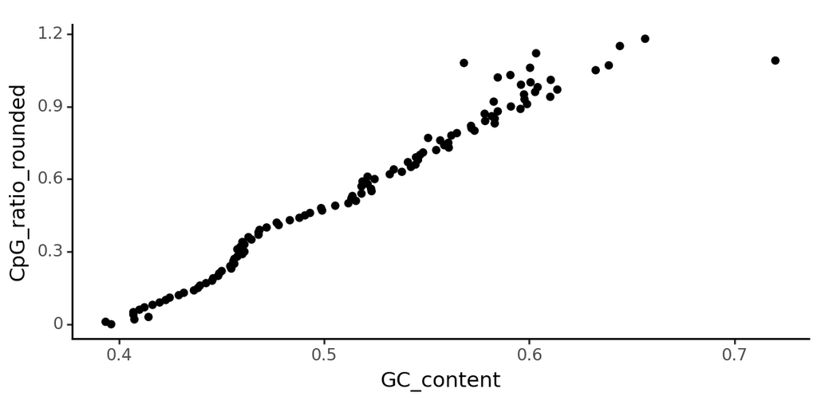

```python
print(gc_vs_cpg_plot)
```

```python
composition_df = pd.DataFrame([[0, .25, .5], [.25, .5, 1.2], [.4, .45, .525], [.45, .525, .65], ['low', 'mid', 'high']]).transpose()
composition_df.columns = ['CpG_ratio_lower', 'CpG_ratio_upper', 'GC_content_lower', 'GC_content_upper', 'group_id']
composition_df
```

|  | CpG_ratio_lower | CpG_ratio_upper | GC_content_lower | GC_content_upper | group_id |
| --- | --- | --- | --- | --- | --- |
| 0 | 0 | 0.25 | 0.4 | 0.45 | low |
| 1 | 0.25 | 0.5 | 0.45 | 0.525 | mid |
| 2 | 0.5 | 1.2 | 0.525 | 0.65 | high |

```python
composition_df.to_csv('tsv/random_seq_composition.tsv', index = False, sep = '\t')
```

## Generate random sequences based on GC content and CpG ratios

We previously tried to generate these sequences truly randomly, but then the GC and CpG features would not agree. There was large incompatibility with getting the above plot relationship to work, so clearly there is a design in base genomic composition that extends beyond "random allocation of nucleotides". Because of this, and because the model was trained with these in vivo sequences and not random sequences, we chose to generate our random set by selecting a random island and shuffling that island. We iterate through different islands until they match our criteria and then save them to our arrays.

Next, we want to loop through these desired criteria. For each iteration, a sequence needs to:

- match GC content
- match CpG content
- be derived from a region sequence that is shuffled

```python
# %%script false --no-raise-error

for i,row in composition_df.iterrows():
    np.random.seed(seed)
    group_id = row['group_id']
    cpg_min = row['CpG_ratio_lower']
    cpg_max = row['CpG_ratio_upper']
    gc_min = row['GC_content_lower']
    gc_max = row['GC_content_upper']

    # ACGT_weights = [(1-gc)/2, gc/2, gc/2, (1-gc)/2]

    npz_path = f'npz/random_seqs_seed_{seed}_input_{input_length}_trials_{trials}_group_{group_id}_gc_{gc_min}_to_{gc_max}_cpg_{cpg_min}_to_{cpg_max}_array.npz'

    if not os.path.exists(npz_path):
        seqs = []
        while len(seqs)<trials:

            #Shuffle a randomly selected sequence and see if it satisfies criteria
            seq_1he = one_hot_encode_sequence(np.random.choice(region_seqs, 1)[0])
            shuffle_1he = shuffle_seqs(seq_1he, num_shufs=1, k=2)[0]

            candidate_seq = one_hot_decode_sequence(shuffle_1he)
            C_counts = candidate_seq.count('C')
            G_counts = candidate_seq.count('G')

            GC_content = (C_counts + G_counts)/input_length
            gc_match = (GC_content >= gc_min) & (GC_content <= gc_max)

            CpG_counts = candidate_seq.count('CG')
            cpg_ratio = calculate_cpg_ratio(C_counts = C_counts, G_counts = G_counts,
                                            CpG_counts = CpG_counts, region_width = input_length)
            cpg_match = (cpg_ratio>=cpg_min) & (cpg_ratio <= cpg_max)

#             Keep sequence if the large and small window both match CpG and CG levels within a certain tolerance
#             This approach maintains same sequences across trials.
#             if (not any(s in candidate_seq for s in blacklisted_seqs)) & cpg_match :
            if cpg_match & gc_match:
                seqs = seqs + [candidate_seq]
                seqs = list(set(seqs)) #In case an identical sequence gets picked.
                sys.stdout.write("\rSeq length %i" % len(seqs))
                sys.stdout.flush()
        seqs_1he = one_hot_encode_sequences(seqs)
        np.savez(npz_path, seqs_1he = seqs_1he)
        print(input_length, ', ', gc_min, ', ', cpg_min)
```

```
Seq length 2562032 ,  0.4 ,  0
Seq length 2562032 ,  0.45 ,  0.25
Seq length 2562032 ,  0.525 ,  0.5
```

Baseline prediction levels of these random sequences will be visualized in later analysis.